# R - In class assignment Wk #2

EL (or your name)

Sept 3, 2019

#### Q1. Read in the file with all the baseball players height, weight and age info (BaseballHeightWeight.csv) as a dataframe and save it as baseball. Then display the structure of the dataframe.

The structure is printed below:

```
## 'data.frame':    1034 obs. of  6 variables:
##  $ Name          : Factor w/ 1032 levels "A.J._Burnett",..: 13 795 818 629 200 135 732 718 67 23 ...
##  $ Team          : Factor w/ 30 levels "ANA","ARZ","ATL",..: 4 4 4 4 4 4 4 4 4 4 ...
##  $ Position      : Factor w/ 9 levels "Catcher","Designated_Hitter",..: 1 1 1 3 3 6 7 9 9 4 ...
##  $ Height.inches.: int  74 74 72 72 73 69 69 71 76 71 ...
##  $ Weight.pounds.: int  180 215 210 210 188 176 209 200 231 180 ...
##  $ Age           : num  23 34.7 30.8 35.4 35.7 ...
```

If str( ) does not show that your variable is a ‘data.frame’, then you’ll need the alternative method to read in the file. Also note that read.csv is just one of the many functions you can use to import data files.

#### Q2. print out the first 5 and the last 3 rows of the dataframe

```
##              Name Team      Position Height.inches. Weight.pounds.   Age
## 1   Adam_Donachie  BAL       Catcher             74            180 22.99
## 2       Paul_Bako  BAL       Catcher             74            215 34.69
## 3 Ramon_Hernandez  BAL       Catcher             72            210 30.78
## 4    Kevin_Millar  BAL First_Baseman             72            210 35.43
## 5     Chris_Gomez  BAL First_Baseman             73            188 35.71
```

```
##                Name Team       Position Height.inches. Weight.pounds.
## 1032 Chris_Narveson  STL Relief_Pitcher             75            205
## 1033  Randy_Keisler  STL Relief_Pitcher             75            190
## 1034    Josh_Kinney  STL Relief_Pitcher             73            195
##        Age
## 1032 25.19
## 1033 31.01
## 1034 27.92
```

#### Q3. Change the headers/column names from Weight.pounds. to weight, from Height.inches. to height, and Age to age.

Done.

#### Q4. Print out the first two lines again to see the new column names.

```
##            Name Team Position height weight   age
## 1 Adam_Donachie  BAL  Catcher     74    180 22.99
## 2     Paul_Bako  BAL  Catcher     74    215 34.69
```

#### Q5. Find the statistics (summary) of the heights, weights, and ages of the players. Using complete sentences, give the reader these summary.

The 5-number summary of height (plus the mean) is (use inline R codes here, not just type in the number by hand) 67, 72, 74, 73.6972921, 75, 83, or in table format:

```
##    Min. 1st Qu.  Median    Mean 3rd Qu.    Max.
##    67.0    72.0    74.0    73.7    75.0    83.0
```

The 5-number summary of weight (plus the mean) is 150, 187, 200, 201.6892546, 215, 290, 1, or in table format:

```
##    Min. 1st Qu.  Median    Mean 3rd Qu.    Max.    NA's
##   150.0   187.0   200.0   201.7   215.0   290.0       1
```

The 5-number summary of age (plus the mean) is 20.9, 25.44, 27.925, 28.7367118, 31.2325, 48.52 in table format:

```
##    Min. 1st Qu.  Median    Mean 3rd Qu.    Max.
##   20.90   25.44   27.93   28.74   31.23   48.52
```

#### Q6. You should find an issue with the weight data with an NA value. Use the subset( ) function, select that data point (save as shyboy) and find out who the shy boy was.

```
##              Name Team         Position height weight   age
## 641 Kirk_Saarloos  CIN Starting_Pitcher     72     NA 27.77
```

#### Q7. Remove shyboy from baseball, and then show the number of observations of the cleaned up dataframe baseball.

After removing the data point with invalid weight data, there are (again, use inline R codes here, not just type in the number by hand) 1033.

#### Q8. Make a quick boxplot of the weight of the players. Use the title( ) function immediately to add a title to the chart. (Try color #0000FF for blue.)

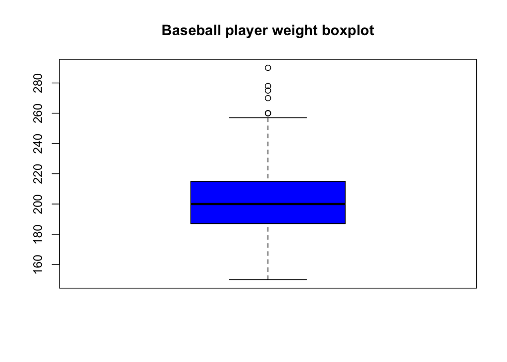

A quick glance from the plot suggest the weight distribution is kind of symmetric, other than a few outliers on the right tail.

#### Q9. Make a histogram of the weight of the players. Try color ‘green’ this time. The function understands the word ‘green’ just fine. Give it a better title than the default. Does the distribution looks normal?

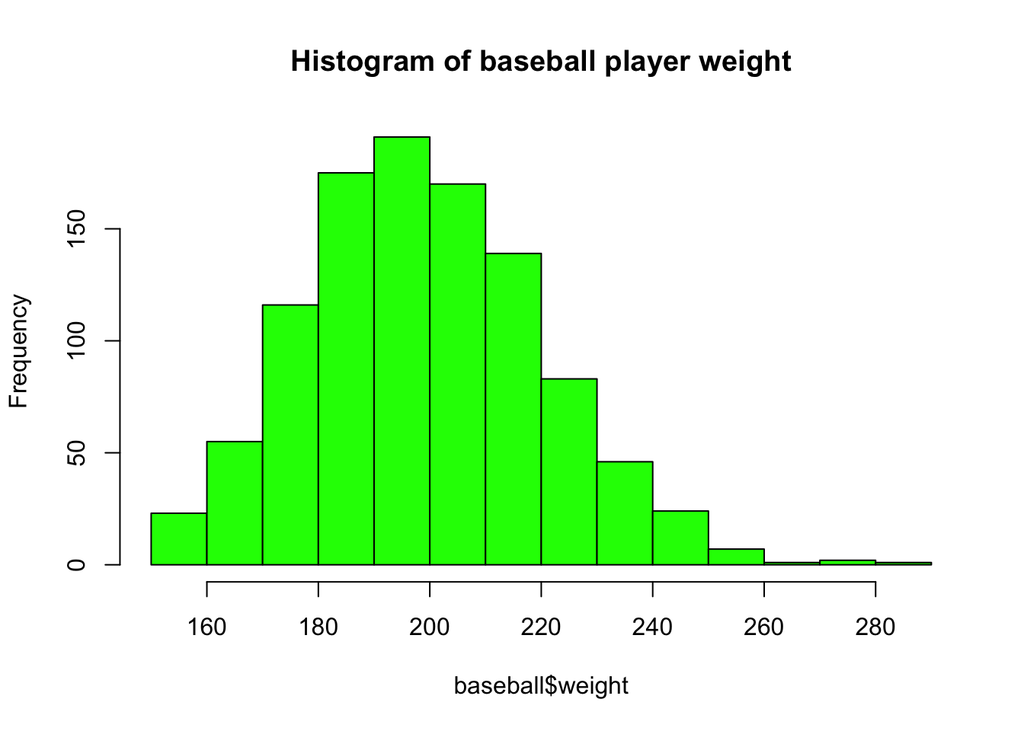

The histogram shows somewhat a normal-looking distribution, with a slight right-skew.

#### Q10. Use ggplot, make a plot with weights vs heights of the players, color by Teams. Give it an appropriate title.

In all scientific literature, a graph is always referred as Y against X (y vs x). Make sure you put “weights” on y as requested here.

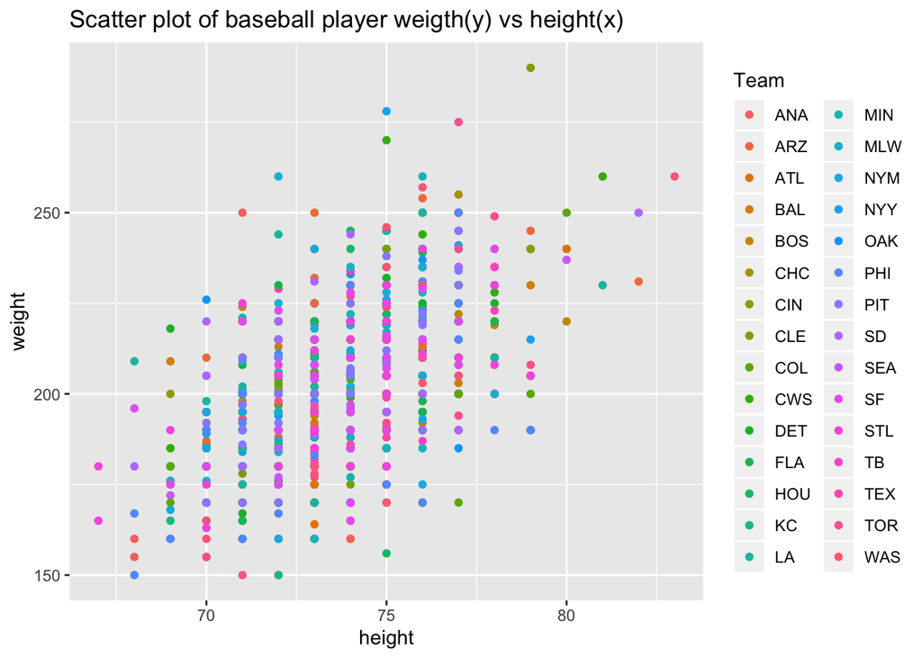

```r
loadPkg("ggplot2")
ggplot(data=baseball)+
  geom_point(mapping = aes(x=height, y=weight, color=Team))+
  ggtitle("Scatter plot of baseball player weigth(y) vs height(x)")
```

#### Q11. Make a plot with weights vs heights of the players, color by age

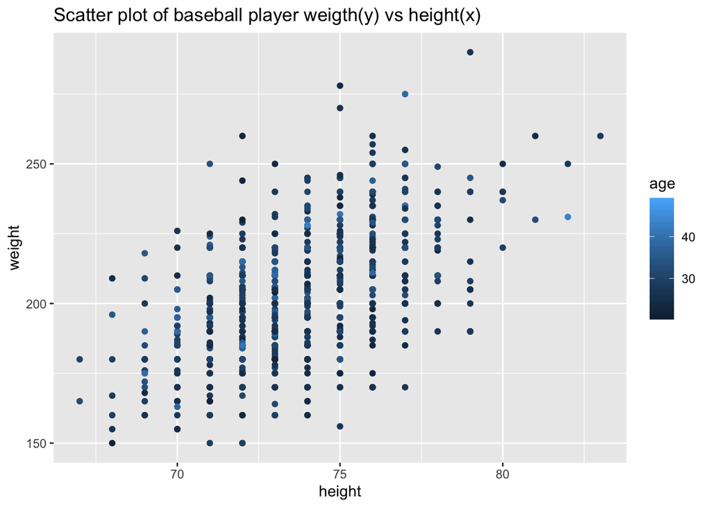

Notice when colored sorted by a discrete variable “Team” and numeric “age”, the plot function handles them slightly differently.

#### Q12. Obtain a subset of the data with only Team Washington. Using complete sentences, give the number of players in Team Washington.

There are 36 in the team.

#### Q13. Obtain another subset with Team Washington and only players older than 28. How many are there in this veteran group?

There are 14 in this category.